# Module 2: R4MS - Workshop 2

Author

Katie Dyck

Published

June 4, 2026

# 1 Introduction

This document includes all material covered from the second “R for Marine Science” workshop: - Tidying data - Pivoting wider and longer - Separating and uniting variables - Dealing with strings and dates - Joining and separating data frames/tibbles - Handling missing values

# 2 Housekeeping

Purge the global environment with the command `rm(list = ls())`.

# 3 Load packages

The `tidyverse`, `here`, `readxl`, and `palmerpenguins` package libraries must be installed and loaded for this module.

# 4 Tidying data

This is what a **tidy** data table looks like:

```r
table1 <- table1
table1
```

| country | year | cases | population |
| --- | --- | --- | --- |
| Afghanistan | 1999 | 745 | 19987071 |
| Afghanistan | 2000 | 2666 | 20595360 |
| Brazil | 1999 | 37737 | 172006362 |
| Brazil | 2000 | 80488 | 174504898 |
| China | 1999 | 212258 | 1272915272 |
| China | 2000 | 213766 | 1280428583 |

Below are two examples of what an **untidy** data table looks like:

```r
table2 <- table2
table2
```

| country | year | type | count |
| --- | --- | --- | --- |
| Afghanistan | 1999 | cases | 745 |
| Afghanistan | 1999 | population | 19987071 |
| Afghanistan | 2000 | cases | 2666 |
| Afghanistan | 2000 | population | 20595360 |
| Brazil | 1999 | cases | 37737 |
| Brazil | 1999 | population | 172006362 |
| Brazil | 2000 | cases | 80488 |
| Brazil | 2000 | population | 174504898 |
| China | 1999 | cases | 212258 |
| China | 1999 | population | 1272915272 |

[output cut: 2 more lines]

```r
table3 <- table3
table3
```

| country | year | rate |
| --- | --- | --- |
| Afghanistan | 1999 | 745/19987071 |
| Afghanistan | 2000 | 2666/20595360 |
| Brazil | 1999 | 37737/172006362 |
| Brazil | 2000 | 80488/174504898 |
| China | 1999 | 212258/1272915272 |
| China | 2000 | 213766/1280428583 |

A tidy dataset follows these 3 interrelated rules:

1. Each variable has its own column
2. Each observation has its own row
3. Each value has its own cell

*All `tidyverse` packages have been designed to work with tidy data.*

# 5 Pivoting data

`pivot_longer()` and `pivot_wider()` are used to reshape data tables. Both functions are made available from the `tidyr` package, which is part of the `tidyverse` library.

```r
table1 |>
  pivot_longer(cols = c("cases", "population"),
               names_to = "case_type",
               values_to = "case_count")
```

| country | year | case_type | case_count |
| --- | --- | --- | --- |
| Afghanistan | 1999 | cases | 745 |
| Afghanistan | 1999 | population | 19987071 |
| Afghanistan | 2000 | cases | 2666 |
| Afghanistan | 2000 | population | 20595360 |
| Brazil | 1999 | cases | 37737 |
| Brazil | 1999 | population | 172006362 |
| Brazil | 2000 | cases | 80488 |
| Brazil | 2000 | population | 174504898 |
| China | 1999 | cases | 212258 |
| China | 1999 | population | 1272915272 |

[output cut: 2 more lines]

```r
table2 |>
  pivot_wider(names_from = "type", values_from = "count")
```

| country | year | cases | population |
| --- | --- | --- | --- |
| Afghanistan | 1999 | 745 | 19987071 |
| Afghanistan | 2000 | 2666 | 20595360 |
| Brazil | 1999 | 37737 | 172006362 |
| Brazil | 2000 | 80488 | 174504898 |
| China | 1999 | 212258 | 1272915272 |
| China | 2000 | 213766 | 1280428583 |

## 5.1 Lengthening datasets

`pivot_longer()` is used to lengthen datasets. It takes multiple columns and collapses them into key-value pairs, **increasing the number of rows** and **decreasing the number of columns**. The dataset is split by the `names_to` argument, which specifies the name of the new column that will contain the *names* of the original columns. The `values_to` argument specifies the name of the new column that will contain the *values* from the original columns.

| artist | track | date.entered | wk1 | wk2 | wk3 | wk4 | wk5 | wk6 | wk7 | wk8 | wk9 | wk10 | wk11 | wk12 | wk13 | wk14 | wk15 | wk16 | wk17 | wk18 | wk19 | wk20 | wk21 | wk22 | wk23 | wk24 | wk25 | wk26 | wk27 | … |
| --- | --- | --- | --- | --- | --- | --- | --- | --- | --- | --- | --- | --- | --- | --- | --- | --- | --- | --- | --- | --- | --- | --- | --- | --- | --- | --- | --- | --- | --- | --- |
| 2 Pac | Baby Don't Cry (Keep... | 2000-02-26 | 87 | 82 | 72 | 77 | 87 | 94 | 99 | NA | NA | NA | NA | NA | NA | NA | NA | NA | NA | NA | NA | NA | NA | NA | NA | NA | NA | NA | NA | … |
| 2Ge+her | The Hardest Part Of ... | 2000-09-02 | 91 | 87 | 92 | NA | NA | NA | NA | NA | NA | NA | NA | NA | NA | NA | NA | NA | NA | NA | NA | NA | NA | NA | NA | NA | NA | NA | NA | … |
| 3 Doors Down | Kryptonite | 2000-04-08 | 81 | 70 | 68 | 67 | 66 | 57 | 54 | 53 | 51 | 51 | 51 | 51 | 47 | 44 | 38 | 28 | 22 | 18 | 18 | 14 | 12 | 7 | 6 | 6 | 6 | 5 | 5 | … |
| 3 Doors Down | Loser | 2000-10-21 | 76 | 76 | 72 | 69 | 67 | 65 | 55 | 59 | 62 | 61 | 61 | 59 | 61 | 66 | 72 | 76 | 75 | 67 | 73 | 70 | NA | NA | NA | NA | NA | NA | NA | … |
| 504 Boyz | Wobble Wobble | 2000-04-15 | 57 | 34 | 25 | 17 | 17 | 31 | 36 | 49 | 53 | 57 | 64 | 70 | 75 | 76 | 78 | 85 | 92 | 96 | NA | NA | NA | NA | NA | NA | NA | NA | NA | … |
| 98^0 | Give Me Just One Nig... | 2000-08-19 | 51 | 39 | 34 | 26 | 26 | 19 | 2 | 2 | 3 | 6 | 7 | 22 | 29 | 36 | 47 | 67 | 66 | 84 | 93 | 94 | NA | NA | NA | NA | NA | NA | NA | … |
| A*Teens | Dancing Queen | 2000-07-08 | 97 | 97 | 96 | 95 | 100 | NA | NA | NA | NA | NA | NA | NA | NA | NA | NA | NA | NA | NA | NA | NA | NA | NA | NA | NA | NA | NA | NA | … |
| Aaliyah | I Don't Wanna | 2000-01-29 | 84 | 62 | 51 | 41 | 38 | 35 | 35 | 38 | 38 | 36 | 37 | 37 | 38 | 49 | 61 | 63 | 62 | 67 | 83 | 86 | NA | NA | NA | NA | NA | NA | NA | … |
| Aaliyah | Try Again | 2000-03-18 | 59 | 53 | 38 | 28 | 21 | 18 | 16 | 14 | 12 | 10 | 9 | 8 | 6 | 1 | 2 | 2 | 2 | 2 | 3 | 4 | 5 | 5 | 6 | 9 | 13 | 14 | 16 | … |
| Adams, Yolanda | Open My Heart | 2000-08-26 | 76 | 76 | 74 | 69 | 68 | 67 | 61 | 58 | 57 | 59 | 66 | 68 | 61 | 67 | 59 | 63 | 67 | 71 | 79 | 89 | NA | NA | NA | NA | NA | NA | NA | … |

[output cut: 307 more lines]

In the `billboard` dataset above, each observation is a song, and the first 3 columns (`artist`, `track`, and `date.entered`) are variables that describe the song. The remaining columns (`wk1` to `wk76`) are not variables, but rather values *of* a variable (week). To tidy this dataset so that each row is a single observation, we can use `pivot_longer()` to collapse the `wk1` to `wk76` columns into key-value pairs.

```r
billboard |>
  pivot_longer(cols = starts_with("wk"),  # so the first 3 columns are not pivoted
               names_to = "week",
               values_to = "rank")
```

| artist | track | date.entered | week | rank |
| --- | --- | --- | --- | --- |
| 2 Pac | Baby Don't Cry (Keep... | 2000-02-26 | wk1 | 87 |
| 2 Pac | Baby Don't Cry (Keep... | 2000-02-26 | wk2 | 82 |
| 2 Pac | Baby Don't Cry (Keep... | 2000-02-26 | wk3 | 72 |
| 2 Pac | Baby Don't Cry (Keep... | 2000-02-26 | wk4 | 77 |
| 2 Pac | Baby Don't Cry (Keep... | 2000-02-26 | wk5 | 87 |
| 2 Pac | Baby Don't Cry (Keep... | 2000-02-26 | wk6 | 94 |
| 2 Pac | Baby Don't Cry (Keep... | 2000-02-26 | wk7 | 99 |
| 2 Pac | Baby Don't Cry (Keep... | 2000-02-26 | wk8 | NA |
| 2 Pac | Baby Don't Cry (Keep... | 2000-02-26 | wk9 | NA |
| 2 Pac | Baby Don't Cry (Keep... | 2000-02-26 | wk10 | NA |

[output cut: 9990 more lines]

As some songs are only on the billboard for a few weeks, there are many `NA` values in the `rank` column. We can use the `values_drop_na` argument in `pivot_longer()` to drop these rows from the output.

```r
billboard |>
  pivot_longer(cols = starts_with("wk"),
               names_to = "week",
               values_to = "rank",
               values_drop_na = TRUE)
```

| artist | track | date.entered | week | rank |
| --- | --- | --- | --- | --- |
| 2 Pac | Baby Don't Cry (Keep... | 2000-02-26 | wk1 | 87 |
| 2 Pac | Baby Don't Cry (Keep... | 2000-02-26 | wk2 | 82 |
| 2 Pac | Baby Don't Cry (Keep... | 2000-02-26 | wk3 | 72 |
| 2 Pac | Baby Don't Cry (Keep... | 2000-02-26 | wk4 | 77 |
| 2 Pac | Baby Don't Cry (Keep... | 2000-02-26 | wk5 | 87 |
| 2 Pac | Baby Don't Cry (Keep... | 2000-02-26 | wk6 | 94 |
| 2 Pac | Baby Don't Cry (Keep... | 2000-02-26 | wk7 | 99 |
| 2Ge+her | The Hardest Part Of ... | 2000-09-02 | wk1 | 91 |
| 2Ge+her | The Hardest Part Of ... | 2000-09-02 | wk2 | 87 |
| 2Ge+her | The Hardest Part Of ... | 2000-09-02 | wk3 | 92 |

[output cut: 5297 more lines]

We can also convert some of the values in the `week` column from character to numeric using the `names_prefix()` argument. This argument allows us to specify a string that will be removed from the values in the `week` column before they are converted to numeric.

```r
billboard |>
  pivot_longer(cols = starts_with("wk"),
               names_to = "week",
               values_to = "rank",
               values_drop_na = TRUE,
               names_prefix = "wk") |>
  mutate(week = as.numeric(week))
```

| artist | track | date.entered | week | rank |
| --- | --- | --- | --- | --- |
| 2 Pac | Baby Don't Cry (Keep... | 2000-02-26 | 1 | 87 |
| 2 Pac | Baby Don't Cry (Keep... | 2000-02-26 | 2 | 82 |
| 2 Pac | Baby Don't Cry (Keep... | 2000-02-26 | 3 | 72 |
| 2 Pac | Baby Don't Cry (Keep... | 2000-02-26 | 4 | 77 |
| 2 Pac | Baby Don't Cry (Keep... | 2000-02-26 | 5 | 87 |
| 2 Pac | Baby Don't Cry (Keep... | 2000-02-26 | 6 | 94 |
| 2 Pac | Baby Don't Cry (Keep... | 2000-02-26 | 7 | 99 |
| 2Ge+her | The Hardest Part Of ... | 2000-09-02 | 1 | 91 |
| 2Ge+her | The Hardest Part Of ... | 2000-09-02 | 2 | 87 |
| 2Ge+her | The Hardest Part Of ... | 2000-09-02 | 3 | 92 |

[output cut: 5297 more lines]

## 5.2 Widening datasets

`pivot_wider()` is used to widen datasets. It allows us to handle a single observation that is spread across *multiple rows*. It takes key-value pairs and spreads them across multiple columns, **decreasing the number of rows** and **increasing the number of columns**.

The dataset is split by the `names_from` argument, which specifies the name of the column that contains the *names* of the new columns. The `values_from` argument specifies the name of the column that contains the *values* that will be spread across the new columns.

| org_pac_id | org_nm | measure_cd | measure_title | prf_rate |
| --- | --- | --- | --- | --- |
| 0446157747 | USC CARE MEDICAL GROUP INC | CAHPS_GRP_1 | CAHPS for MIPS SSM: Getting Timely Care, Appointments, and Information | 63 |
| 0446157747 | USC CARE MEDICAL GROUP INC | CAHPS_GRP_2 | CAHPS for MIPS SSM: How Well Providers Communicate | 87 |
| 0446157747 | USC CARE MEDICAL GROUP INC | CAHPS_GRP_3 | CAHPS for MIPS SSM: Patient's Rating of Provider | 86 |
| 0446157747 | USC CARE MEDICAL GROUP INC | CAHPS_GRP_5 | CAHPS for MIPS SSM: Health Promotion and Education | 57 |
| 0446157747 | USC CARE MEDICAL GROUP INC | CAHPS_GRP_8 | CAHPS for MIPS SSM: Courteous and Helpful Office Staff | 85 |
| 0446157747 | USC CARE MEDICAL GROUP INC | CAHPS_GRP_12 | CAHPS for MIPS SSM: Stewardship of Patient Resources | 24 |
| 0446162697 | ASSOCIATION OF UNIVERSITY PHYSICIANS | CAHPS_GRP_1 | CAHPS for MIPS SSM: Getting Timely Care, Appointments, and Information | 59 |
| 0446162697 | ASSOCIATION OF UNIVERSITY PHYSICIANS | CAHPS_GRP_2 | CAHPS for MIPS SSM: How Well Providers Communicate | 85 |
| 0446162697 | ASSOCIATION OF UNIVERSITY PHYSICIANS | CAHPS_GRP_3 | CAHPS for MIPS SSM: Patient's Rating of Provider | 83 |
| 0446162697 | ASSOCIATION OF UNIVERSITY PHYSICIANS | CAHPS_GRP_5 | CAHPS for MIPS SSM: Health Promotion and Education | 63 |

[output cut: 490 more lines]

The unit being studied in the `cms_patient_experience` dataset above (from the `tidyr` package) is an organization. In the current format, though, each organization (currently in the `org_nm` column) is spread over 6 rows with 1 row for each of the 6 measurements taken during the survey.

```r
cms_patient_experience |>
  distinct(measure_cd, measure_title)
```

| measure_cd | measure_title |
| --- | --- |
| CAHPS_GRP_1 | CAHPS for MIPS SSM: Getting Timely Care, Appointments, and Information |
| CAHPS_GRP_2 | CAHPS for MIPS SSM: How Well Providers Communicate |
| CAHPS_GRP_3 | CAHPS for MIPS SSM: Patient's Rating of Provider |
| CAHPS_GRP_5 | CAHPS for MIPS SSM: Health Promotion and Education |
| CAHPS_GRP_8 | CAHPS for MIPS SSM: Courteous and Helpful Office Staff |
| CAHPS_GRP_12 | CAHPS for MIPS SSM: Stewardship of Patient Resources |

To tidy this dataset so that each row is a single observation, we use `pivot_wider()` to spread the values in the `measure` column across multiple columns.

```r
cms_patient_experience |>
  pivot_wider(id_cols = starts_with("org"),   # tells pivot_wider which columns have values that are unique to each row
              names_from = measure_title,
              values_from = prf_rate)
```

| org_pac_id | org_nm | CAHPS for MIPS SSM: Getting Timely Care, Appointments, and Information | CAHPS for MIPS SSM: How Well Providers Communicate | CAHPS for MIPS SSM: Patient's Rating of Provider | CAHPS for MIPS SSM: Health Promotion and Education | CAHPS for MIPS SSM: Courteous and Helpful Office Staff | CAHPS for MIPS SSM: Stewardship of Patient Resources |
| --- | --- | --- | --- | --- | --- | --- | --- |
| 0446157747 | USC CARE MEDICAL GROUP INC | 63 | 87 | 86 | 57 | 85 | 24 |
| 0446162697 | ASSOCIATION OF UNIVERSITY PHYSICIANS | 59 | 85 | 83 | 63 | 88 | 22 |
| 0547164295 | BEAVER MEDICAL GROUP PC | 49 | NA | 75 | 44 | 73 | 12 |
| 0749333730 | CAPE PHYSICIANS ASSOCIATES PA | 67 | 84 | 85 | 65 | 82 | 24 |
| 0840104360 | ALLIANCE PHYSICIANS INC | 66 | 87 | 87 | 64 | 87 | 28 |
| 0840109864 | REX HOSPITAL INC | 73 | 87 | 84 | 67 | 91 | 30 |
| 0840513552 | SCL HEALTH MEDICAL GROUP DENVER LLC | 58 | 83 | 76 | 58 | 78 | 26 |
| 0941545784 | GRITMAN MEDICAL CENTER INC | 46 | 86 | 81 | 54 | NA | 25 |
| 1052612785 | COMMUNITY MEDICAL GROUP LLC | 65 | 84 | 80 | 58 | 87 | 29 |
| 1254237779 | OUR LADY OF LOURDES MEMORIAL HOSPITAL, INC | 61 | NA | NA | 65 | NA | 17 |

[output cut: 85 more lines]

# 6 Pivot exercise with Palmer Penguins data

| species | island | bill_length_mm | bill_depth_mm | flipper_length_mm | body_mass_g | sex | year |
| --- | --- | --- | --- | --- | --- | --- | --- |
| Adelie | Torgersen | 39.1 | 18.7 | 181 | 3750 | male | 2007 |
| Adelie | Torgersen | 39.5 | 17.4 | 186 | 3800 | female | 2007 |
| Adelie | Torgersen | 40.3 | 18.0 | 195 | 3250 | female | 2007 |
| Adelie | Torgersen | NA | NA | NA | NA | NA | 2007 |
| Adelie | Torgersen | 36.7 | 19.3 | 193 | 3450 | female | 2007 |
| Adelie | Torgersen | 39.3 | 20.6 | 190 | 3650 | male | 2007 |
| Adelie | Torgersen | 38.9 | 17.8 | 181 | 3625 | female | 2007 |
| Adelie | Torgersen | 39.2 | 19.6 | 195 | 4675 | male | 2007 |
| Adelie | Torgersen | 34.1 | 18.1 | 193 | 3475 | NA | 2007 |
| Adelie | Torgersen | 42.0 | 20.2 | 190 | 4250 | NA | 2007 |

[output cut: 334 more lines]

We want to make a single plot that shows the distribution of *all* morphometric measurements (`bill_length_mm`, `bill_depth_mm`, `flipper_length_mm`, and `body_mass_g`). To plot using `facet_wrap()`, we need to stack the variables into 2 columns: one for measurement name, and one for numerical measurement value.

```r
penguins_long <- penguins |>
  pivot_longer(cols = c(bill_length_mm, bill_depth_mm, flipper_length_mm, body_mass_g),
               names_to = "measurement_type",
               values_to = "value")

penguins_long
```

| species | island | sex | year | measurement_type | value |
| --- | --- | --- | --- | --- | --- |
| Adelie | Torgersen | male | 2007 | bill_length_mm | 39.1 |
| Adelie | Torgersen | male | 2007 | bill_depth_mm | 18.7 |
| Adelie | Torgersen | male | 2007 | flipper_length_mm | 181.0 |
| Adelie | Torgersen | male | 2007 | body_mass_g | 3750.0 |
| Adelie | Torgersen | female | 2007 | bill_length_mm | 39.5 |
| Adelie | Torgersen | female | 2007 | bill_depth_mm | 17.4 |
| Adelie | Torgersen | female | 2007 | flipper_length_mm | 186.0 |
| Adelie | Torgersen | female | 2007 | body_mass_g | 3800.0 |
| Adelie | Torgersen | female | 2007 | bill_length_mm | 40.3 |
| Adelie | Torgersen | female | 2007 | bill_depth_mm | 18.0 |

[output cut: 1366 more lines]

Using the transformed data table above, we can plot the distribution of all morphometric measurements.

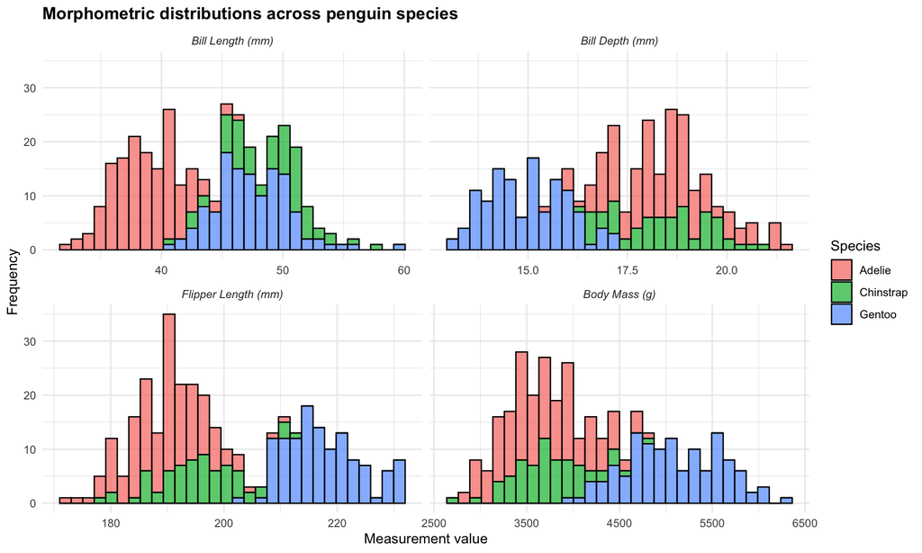

```r
penguins_long |>
  drop_na(value) |>
  mutate(
    # Create a new factor variable with desired labels for facets
    measurement_type_labeled = factor(measurement_type,
      levels = c(
        "bill_length_mm", "bill_depth_mm",
        "flipper_length_mm", "body_mass_g"
      ),
      labels = c(
        "Bill Length (mm)", "Bill Depth (mm)",
        "Flipper Length (mm)", "Body Mass (g)"
      )
    )
  ) |>
  ggplot(aes(x = value, fill = species)) +
  geom_histogram(bins = 30, alpha = 0.7, colour = "black") +
  # Use the new labeled variable for faceting
  facet_wrap(~ measurement_type_labeled, scales = "free_x") +
  theme_minimal() +
  labs(
    title = "Morphometric distributions across penguin species",
    x = "Measurement value",
    y = "Frequency"
  ) +
  theme(
    plot.title = element_text(face = "bold"),
    strip.text = element_text(face = "italic", colour = "grey20")
  ) +
  scale_fill_discrete(name = "Species")
```

We can also widen the original `penguins` data set to present summary statistics. This is known as a **cross-tabulated matrix**.

```r
mass_summary <- penguins |>
  drop_na(body_mass_g) |>
  group_by(species, island) |>
  summarise(mean_mass = mean(body_mass_g))

mass_summary
```

| species | island | mean_mass |
| --- | --- | --- |
| Adelie | Biscoe | 3709.659 |
| Adelie | Dream | 3688.393 |
| Adelie | Torgersen | 3706.373 |
| Chinstrap | Dream | 3733.088 |
| Gentoo | Biscoe | 5076.016 |

To create a cross-tabulated matrix that is more appropriate for publication, we can use `pivot_wider()` to spread the `island` variable across multiple columns.

```r
mass_matrix <- mass_summary |>
  pivot_wider(names_from = island,     # which column provides new column headers
              values_from = mean_mass)   # which columns provides values to fill new columns

mass_matrix
```

| species | Biscoe | Dream | Torgersen |
| --- | --- | --- | --- |
| Adelie | 3709.659 | 3688.393 | 3706.373 |
| Chinstrap | NA | 3733.088 | NA |
| Gentoo | 5076.016 | NA | NA |

(NA values indicate that no penguins were found on the island.)

# 7 Separating and uniting data tables

| country | year | rate |
| --- | --- | --- |
| Afghanistan | 1999 | 745/19987071 |
| Afghanistan | 2000 | 2666/20595360 |
| Brazil | 1999 | 37737/172006362 |
| Brazil | 2000 | 80488/174504898 |
| China | 1999 | 212258/1272915272 |
| China | 2000 | 213766/1280428583 |

## 7.1 `separate()`

In the table above, the `rate` column needs to be split into a `cases` and `population` column. The `separate()` function from the `tidyr` package can be used to split a single column into multiple columns.

```r
table3 |>
  separate(rate, into = c("cases", "population"))
```

| country | year | cases | population |
| --- | --- | --- | --- |
| Afghanistan | 1999 | 745 | 19987071 |
| Afghanistan | 2000 | 2666 | 20595360 |
| Brazil | 1999 | 37737 | 172006362 |
| Brazil | 2000 | 80488 | 174504898 |
| China | 1999 | 212258 | 1272915272 |
| China | 2000 | 213766 | 1280428583 |

`separate()` defaults to splitting values by any non-alphanumeric character it sees. In this instance, it split the `rate` column based on the “/” character. If we wanted to split the `rate` column based on a different character, we could use the `sep` argument to specify the separator.

```r
table3 |>
  separate(rate, into = c("cases", "population"), sep = "/")
# gives the same output as the previous code chunk
```

The `cases` and `population` columns need to be converted to numeric types. They are currently character types because this is the default when using `separate()`. There are 2 ways this can be done:

```r
table3 |>
  separate(rate, into = c("cases", "population"), sep = "/") |>
  mutate(cases = as.numeric(cases),
         population = as.numeric(population))
```

OR

```r
table3 |>
  separate(rate, into = c("cases", "population"), sep = "/", convert = TRUE)
```

| country | year | cases | population |
| --- | --- | --- | --- |
| Afghanistan | 1999 | 745 | 19987071 |
| Afghanistan | 2000 | 2666 | 20595360 |
| Brazil | 1999 | 37737 | 172006362 |
| Brazil | 2000 | 80488 | 174504898 |
| China | 1999 | 212258 | 1272915272 |
| China | 2000 | 213766 | 1280428583 |

When you pass an integer to the `sep` argument, `separate()` will split the column at that position. For example, if we wanted to split the `year` column into a `century` and `year` column, we could use `sep = 2` to split the column after the first 2 characters.

```r
table3 |>
  separate(year, into = c("century", "year"), sep = 2)
```

| country | century | year | rate |
| --- | --- | --- | --- |
| Afghanistan | 19 | 99 | 745/19987071 |
| Afghanistan | 20 | 00 | 2666/20595360 |
| Brazil | 19 | 99 | 37737/172006362 |
| Brazil | 20 | 00 | 80488/174504898 |
| China | 19 | 99 | 212258/1272915272 |
| China | 20 | 00 | 213766/1280428583 |

## 7.2 `unite()`

`unite()` is the opposite of `separate()`. It combines multiple columns into a single column. The `col` argument specifies the name of the new column that will be created, and the `sep` argument specifies the separator that will be used to combine the values from the original columns.

| country | century | year | rate |
| --- | --- | --- | --- |
| Afghanistan | 19 | 99 | 745/19987071 |
| Afghanistan | 20 | 00 | 2666/20595360 |
| Brazil | 19 | 99 | 37737/172006362 |
| Brazil | 20 | 00 | 80488/174504898 |
| China | 19 | 99 | 212258/1272915272 |
| China | 20 | 00 | 213766/1280428583 |

```r
table5 |>
  unite(col = new, century, year, sep = "")   # no separator - default is "_"
```

| country | new | rate |
| --- | --- | --- |
| Afghanistan | 1999 | 745/19987071 |
| Afghanistan | 2000 | 2666/20595360 |
| Brazil | 1999 | 37737/172006362 |
| Brazil | 2000 | 80488/174504898 |
| China | 1999 | 212258/1272915272 |
| China | 2000 | 213766/1280428583 |

# 8 Wrangling strings and data

## 8.1 `stringr` package

The `stringr` package library contains several functions for working with strings, all of which begin with “str_”.

Look how messy this data frame of field site names is:

```
# A tibble: 5 × 1
  site_id
  <chr>
1 " Nelly Bay"
2 "nelly_bay"
3 "NELLY BAY"
4 " Geoffrey_Bay "
5 "geoffrey bay"
```

We can use `stringr` within `mutate()` to standardize the text:

```r
clean_sites <- messy_sites |>
  mutate(
    # 1. Convert everything to lowercase
    site_clean = str_to_lower(site_id),
    # 2. Replace any spaces with underscores
    site_clean = str_replace_all(site_clean, pattern = " ", replacement = "_"),
    # 3. Trim any leading or trailing whitespace (invisible spaces at the ends)
    site_clean = str_trim(site_clean),
    # 4. Remove any trailing or leading underscores
    site_clean = str_replace_all(site_clean, pattern = "^_+|_+$", replacement = ""),
    # 5. Replace underscores with spaces
    site_clean = str_replace_all(site_clean, pattern = "_", replacement = " "),
    # 6. Convert to title case (first letter of each word capitalized)
    site_clean = str_to_title(site_clean)
  )

clean_sites
```

| site_id | site_clean |
| --- | --- |
| Nelly Bay | Nelly Bay |
| nelly_bay | Nelly Bay |
| NELLY BAY | Nelly Bay |
| Geoffrey_Bay | Geoffrey Bay |
| geoffrey bay | Geoffrey Bay |